# LRR des poissons d’eau douce de BFC

49_question_GLMM

PabloVigneron

2026-06-16

Script : 49_question_GLMM # Installation

Chargement des packages, fonctions et des données

```r
library(lme4)
library(aspe)
library(tidyverse)
library(aspe)
library(sjstats)
library(gt)
library(glmmTMB)
library(RVAideMemoire)
# library(lmerTest)  # remplace lme4 automatiquement
library(ggh4x)
library(mgcv) # modele GAMMs
library(gratia)
library(patchwork)
library(lme4)
library(car) # fonction Anova()
library(gstat)#semi_variogramme
library(DHARMa) # Ajusting of the model
library(ggplotify)
library(ggpubr)
```

```r
load(file = "../processed_data/selection_especes.rda")
load(file = "../processed_data/selection_pop_ope.rda")
load(file = "../processed_data/donnees_densite_eff_abs.rda")
load(file = "../processed_data/assemblage_tab_par_ope.rda")
```

```r
source(file = "../R/zip_glmm_calcul_modele.R")
source(file = "../R/zip_glmm_application_modele.R")
source(file = "../R/gamm_calcul_modele.R")
source(file = "../R/gamm_application_modele.R")
source(file = "../R/adequate_data_for_model.R")
```

```r
rdata_tables <- misc_nom_dernier_fichier(
  repertoire = "../../../../Liste_rouge_BFC/raw_data",
  pattern = "^tables")
load(rdata_tables) # Chargement des données
```

## 0.1 Contexte du stage

L’objectif principal de l’étude est d’évaluer les tendances démographiques des espèces de poissons d’eau douce à l’échelle de la région Bourgogne Franche-comté. Des séries chronologiques longues enregistrant plus d’une dizaine d’années ou 3 générations (critère A UICN) de données seront utilisées (sur un total disponible d’une vingtaine d’années). Ce travail s’inscrit dans la perspective de la création de la Liste rouge régionale des poissons d’eau douce de Bourgogne Franche-Comté et compte une trentaine d’espèces à évaluer.

L’OFB a mis en place depuis 1990 des réseaux de suivi temporel de l’état des milieux aquatiques à partir des peuplements de poissons. Les échantillonnages sont réalisés tous les ans ou tout les deux ans en fonction des réseaux pluriannuels des stations identiques selon deux protocoles distincts : - pêche par points (partielle) - pêche complète

L’ensemble des données sont stocké dans la base de données **aspe** de l’OFB.

Les tendances temporelles seront estimées par une analyse statistique de Modèles Additifs Généralisé Mixtes (GAMMs), de Modèles Linéaires Généralisé Mixtes (GLMM) ou de Zero-Inflated GLMM (ZIGLMM) ou Hurdle GLMM (HGLMM) en fonction de l’ajustement des modèles aux données.

# 1 Choix des variables

Pour répondre à la question initiale, les modèles vont se construire à partir des variables suivantes :

La variable réponse : **valeur**, effectif des poissons *variable quantitative discrète bornée*

Les variables explicatives :

les co-variables :

- **annee**, *variable quantitative discrète bornée*
- **ope_surface_calculee**, la surface pêchée *variable quantitative continue bornée*

les facteurs :

- **pro_libelle**, les protocoles utilisés (2 modalitées) *variable qualitative nominal*
- **sta_id**, les stations d’échantillonages (163 modalitées) *variable qualitative nominal*

# 2 Exemple d’analyse avec la Truite Fario (TRF)

## 2.1 **Preparation du df avec absences**

```r
# preparer la table pour jointure
ope_selection <- ope_selection %>%
  dplyr::select(ope_id, pop_id, sta_id)

# Ajout des coordonnées pour jointure avec df pour future analyse autocorrelation spatiale
coord_sta_id <- point_prelevement %>%
  filter(pop_id %in% pop_serie_tempo) %>%
  rename(x = pop_coordonnees_x, y = pop_coordonnees_y) %>%
  select(pop_id, x, y) %>%
  mutate(pop_id = as.factor(pop_id))

# prepéarer la table pour jointure
esp_ope_selection_join <- esp_ope_selection %>%
  select(ope_id, ope_surface_calculee) %>%
  distinct(ope_id, .keep_all = TRUE)


ope_effectif_glmm_abs <- ope_effectif_absences %>%
  mef_ajouter_type_protocole() %>%
  left_join(ope_selection, by = "ope_id") %>%
  inner_join(esp_ope_selection_join, by = "ope_id") %>%
  mutate(
    valeur = as.numeric(valeur) ,
    annee = as.numeric(annee),
    ope_surface_calculee = as.numeric(ope_surface_calculee),
    pro_libelle = as.factor(pro_libelle),
    pop_id = as.factor(pop_id),
    sta_id = as.factor(sta_id),
    stade = as.factor(stade)
  ) %>%
  left_join(coord_sta_id, by = "pop_id") %>%
  mutate(x = as.numeric(x),
         y = as.numeric(y))%>%
  rename(espece = esp_code_alternatif)
```

```r
truite_data_abs <- ope_effectif_glmm_abs %>%
  filter(espece == "TRF")
```

```r
head(truite_data_abs)
```

```
## # A tibble: 6 × 12
##   ope_id espece indicateur     valeur stade pro_libelle      annee pop_id sta_id
##    <int> <chr>  <chr>           <dbl> <fct> <fct>            <dbl> <fct>  <fct>
## 1  11207 TRF    effectif_total      0 ind   Pêche complète …  2014 67123  18684
## 2  11280 TRF    effectif_total      2 ind   Pêche complète …  2016 67123  18684
## 3  11903 TRF    effectif_total    105 ind   Pêche complète …  2016 81644  24171
## 4  11904 TRF    effectif_total    182 ind   Pêche complète …  2014 81644  24171
## 5  11905 TRF    effectif_total    125 ind   Pêche complète …  2012 81644  24171
## 6  11906 TRF    effectif_total    160 ind   Pêche complète …  2010 81644  24171
## # ℹ 3 more variables: ope_surface_calculee <dbl>, x <dbl>, y <dbl>
```

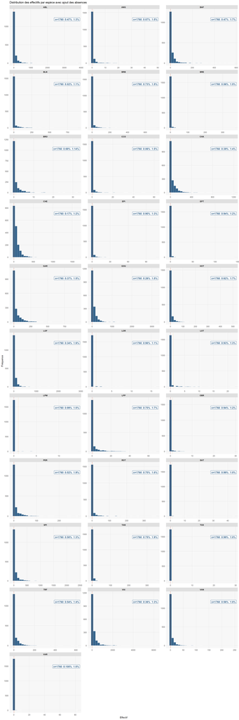

```r
stats_esp <- ope_effectif_glmm_abs %>%
  group_by(espece) %>%
  summarise(
    pct_zero  = mean(valeur == 0) * 100,
    pct_un    = mean(valeur == 1) * 100,
    pct_zero1 = mean(valeur <= 1) * 100,
    n         = n(),
    .groups   = "drop"
  ) %>%
  mutate(
    label = paste0(
      "n=", n,
      "  0:", round(pct_zero), "%",
      "  1:", round(pct_un), "%"))

histogram_esp <- ggplot(data = ope_effectif_glmm_abs, aes(x = valeur)) +
  facet_wrap2(
    ~ espece,
    ncol   = 3,
    scales = "free",
    axes   = "all",
    trim_blank = TRUE
  ) +
  geom_histogram(bins = 30, fill = "steelblue4", color = "white", linewidth = 0.2) +
  geom_vline(xintercept = 0, color = "firebrick", linetype = "dashed", linewidth = 0.5) +
  geom_vline(xintercept = 1, color = "darkorange", linetype = "dotted",  linewidth = 0.5) +
  geom_label(
    data    = stats_esp,
    mapping = aes(x = Inf, y = Inf, label = label),
    hjust   = 1.05, vjust = 3.5,
    size    = 4, fontface = "bold",
    fill    = "white", color = "steelblue4", label.size = 0.5

  ) +
  scale_x_continuous() +
  scale_y_continuous() +
  labs(
    x     = "Effectif",
    y     = "Fréquence",
    title = "Distribution des effectifs par espèce avec ajout des absences",
  ) +
  theme_minimal(base_size = 11) +
  theme(
    strip.background = element_rect(fill = "grey88", color = NA),
    strip.text       = element_text(face = "bold", size = 9),
    panel.background = element_rect(fill = "grey97", color = NA),
    panel.grid.major = element_line(color = "grey90"),
    panel.grid.minor = element_blank(),
    plot.caption     = element_text(size = 8, color = "grey50")
  )

histogram_esp
```

## 2.2 **Preparation du df sans absences**

```r
# preparer la table pour jointure
ope_selection <- ope_selection %>%
  dplyr::select(ope_id, pop_id, sta_id)

# Ajout des coordonnées pour jointure avec df pour future analyse autocorrelation spatiale
coord_sta_id <- point_prelevement %>%
  filter(pop_id %in% pop_serie_tempo) %>%
  rename(x = pop_coordonnees_x, y = pop_coordonnees_y) %>%
  select(pop_id, x, y) %>%
  mutate(pop_id = as.factor(pop_id))

# prepéarer la table pour jointure
esp_ope_selection_join <- esp_ope_selection %>%
  select(ope_id, ope_surface_calculee) %>%
  distinct(ope_id, .keep_all = TRUE)


ope_effectif_glmm_sans_abs <- ope_effectif %>%
  mef_ajouter_type_protocole() %>%
  left_join(ope_selection, by = "ope_id") %>%
  inner_join(esp_ope_selection_join, by = "ope_id") %>%
  mutate(
    valeur = as.numeric(valeur) ,
    annee = as.numeric(annee),
    ope_surface_calculee = as.numeric(ope_surface_calculee),
    pro_libelle = as.factor(pro_libelle),
    pop_id = as.factor(pop_id),
    sta_id = as.factor(sta_id),
    stade = as.factor(stade)
  ) %>%
  left_join(coord_sta_id, by = "pop_id") %>%
  mutate(x = as.numeric(x),
         y = as.numeric(y))%>%
  rename(espece = esp_code_alternatif) %>%
  filter(stade == "ind") # Filtrer les stades, ici les indetermines
```

```r
truite_data_sans_abs <- ope_effectif_glmm_sans_abs %>%
  filter(espece == "TRF")
```

```r
head(truite_data_sans_abs)
```

```
## # A tibble: 6 × 12
##   ope_id espece indicateur     valeur stade pro_libelle      annee pop_id sta_id
##    <int> <chr>  <chr>           <dbl> <fct> <fct>            <dbl> <fct>  <fct>
## 1  11280 TRF    effectif_total      2 ind   Pêche complète …  2016 67123  18684
## 2  11903 TRF    effectif_total    105 ind   Pêche complète …  2016 81644  24171
## 3  11904 TRF    effectif_total    182 ind   Pêche complète …  2014 81644  24171
## 4  11905 TRF    effectif_total    125 ind   Pêche complète …  2012 81644  24171
## 5  11906 TRF    effectif_total    160 ind   Pêche complète …  2010 81644  24171
## 6  11907 TRF    effectif_total    167 ind   Pêche complète …  2008 81644  24171
## # ℹ 3 more variables: ope_surface_calculee <dbl>, x <dbl>, y <dbl>
```

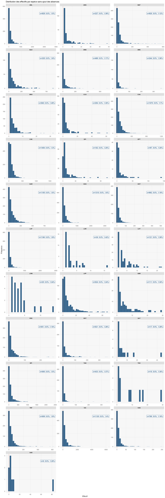

```r
stats_esp_sans_abs <- ope_effectif_glmm_sans_abs %>%
  group_by(espece) %>%
  summarise(
    pct_zero  = mean(valeur == 0) * 100,
    pct_un    = mean(valeur == 1) * 100,
    pct_zero1 = mean(valeur <= 1) * 100,
    n         = n(),
    .groups   = "drop"
  ) %>%
  mutate(
    label = paste0(
      "n=", n,
      "  0:", round(pct_zero), "%",
      "  1:", round(pct_un), "%"))

histogram_esp_sans_abs <- ggplot(data = ope_effectif_glmm_sans_abs, aes(x = valeur)) +
  facet_wrap2(
    ~ espece,
    ncol   = 3,
    scales = "free",
    axes   = "all",
    trim_blank = TRUE
  ) +
  geom_histogram(bins = 30, fill = "steelblue4", color = "white", linewidth = 0.2) +
  geom_vline(xintercept = 0, color = "firebrick", linetype = "dashed", linewidth = 0.5) +
  geom_vline(xintercept = 1, color = "darkorange", linetype = "dotted",  linewidth = 0.5) +
  geom_label(
    data    = stats_esp_sans_abs,
    mapping = aes(x = Inf, y = Inf, label = label),
    hjust   = 1.05, vjust = 3.5,
    size    = 4, fontface = "bold",
    fill    = "white", color = "steelblue4", label.size = 0.5

  ) +
  scale_x_continuous() +
  scale_y_continuous() +
  labs(
    x     = "Effectif",
    y     = "Fréquence",
    title = "Distribution des effectifs par espèce sans ajout des absences",
  ) +
  theme_minimal(base_size = 11) +
  theme(
    strip.background = element_rect(fill = "grey88", color = NA),
    strip.text       = element_text(face = "bold", size = 9),
    panel.background = element_rect(fill = "grey97", color = NA),
    panel.grid.major = element_line(color = "grey90"),
    panel.grid.minor = element_blank(),
    plot.caption     = element_text(size = 8, color = "grey50")
  )

histogram_esp_sans_abs
```

# 3 Zero-Inflated GLMM (ZIGLMM) ou Hurdle GLMM (HGLMM) AVEC ABSENCE

```r
mod_zi_1.0 <- glmmTMB(
  valeur ~ annee + offset(log(ope_surface_calculee)) +pro_libelle + (1 |
                                                           sta_id) ,
  data = truite_data_abs,
  family = poisson(link = "log"),
  ziformula = ~ 1
)
mod_zi_1.1 <- glmmTMB(
  valeur ~ annee + offset(log(ope_surface_calculee)) + pro_libelle + (1 | sta_id) ,
  family = nbinom2(link = "log"),
  data = truite_data_abs,
  ziformula = ~ 1
)
mod_zi_1.2 <- glmmTMB(
  valeur ~ annee + offset(log(ope_surface_calculee)) + pro_libelle + (1 | sta_id) ,
  family = truncated_poisson(link = "log"),
  data = truite_data_abs,
  ziformula = ~ 1
)
mod_zi_1.3 <- glmmTMB(
  valeur ~ annee + offset(log(ope_surface_calculee)) + pro_libelle + (1 | sta_id) ,
  family = truncated_nbinom2(link = "log"),
  data = truite_data_abs,
  ziformula = ~ 1
)
```

On selectionne à l’aide du critère AIC le meilleur modèle c’est à dire le modèle avec le plus petit AIC.

```r
AIC(mod_zi_1.0, mod_zi_1.1, mod_zi_1.2, mod_zi_1.3)
```

```
##            df       AIC
## mod_zi_1.0  5 13700.722
## mod_zi_1.1  6  7000.222
## mod_zi_1.2  5 15234.411
## mod_zi_1.3  6  8597.858
```

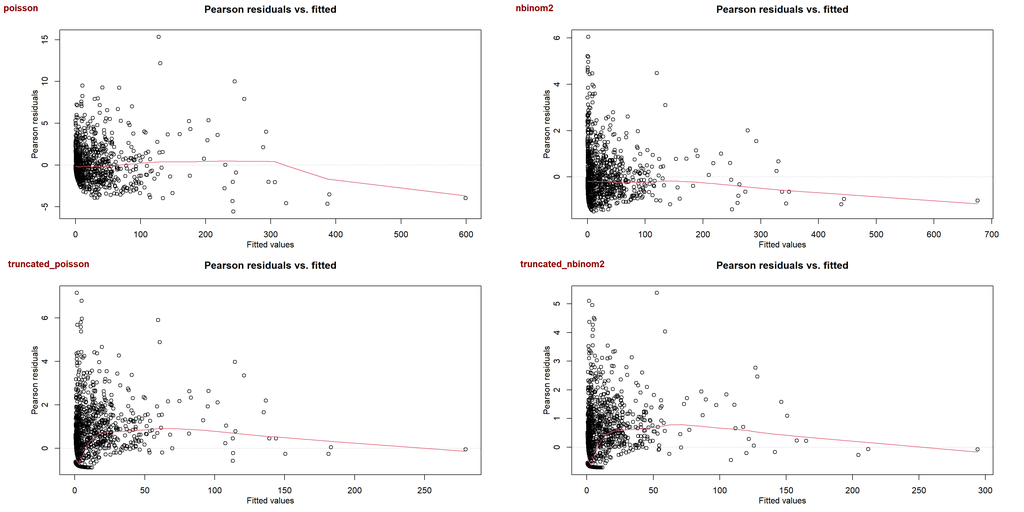

```r
res_mod_zi_1.0 <- as.ggplot(~ plotresid(mod_zi_1.0))
res_mod_zi_1.1 <- as.ggplot(~ plotresid(mod_zi_1.1))
res_mod_zi_1.2 <- as.ggplot(~ plotresid(mod_zi_1.2))
res_mod_zi_1.3 <- as.ggplot(~ plotresid(mod_zi_1.3))

ggarrange(
  res_mod_zi_1.0,
  res_mod_zi_1.1,
  res_mod_zi_1.2,
  res_mod_zi_1.3,
  ncol = 2,
  nrow = 2,
  labels = c("poisson", "nbinom2", "truncated_poisson", "truncated_nbinom2"),
  font.label = list(
    size = 13,
    color = "darkred",
    face = "bold",
    family = NULL
  ),
  hjust = -0.1,
  vjust = 1.6,
  align = c("none", "h", "v", "hv")
)
```

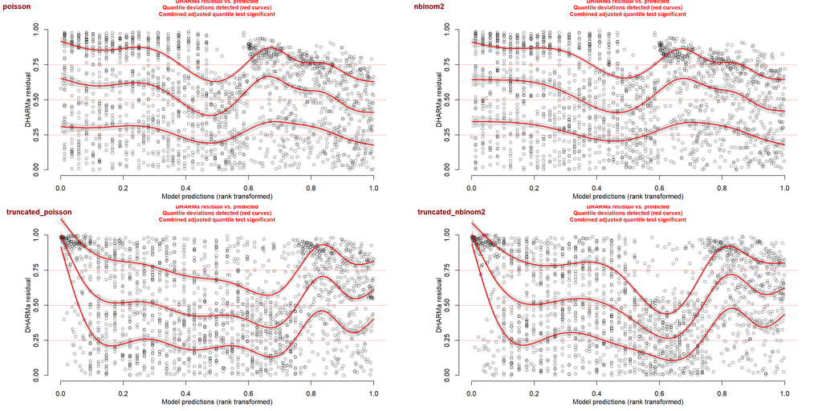

```r
sim_res_mod_zi_1.0 <- as.ggplot(~ plotResiduals(simulateResiduals(fittedModel = mod_zi_1.0, n = 1000), quantreg = T))
sim_res_mod_zi_1.1 <- as.ggplot(~ plotResiduals(simulateResiduals(fittedModel = mod_zi_1.1, n = 1000), quantreg = T))
sim_res_mod_zi_1.2 <- as.ggplot(~ plotResiduals(simulateResiduals(fittedModel = mod_zi_1.2, n = 1000), quantreg = T))
sim_res_mod_zi_1.3 <- as.ggplot(~ plotResiduals(simulateResiduals(fittedModel = mod_zi_1.3, n = 1000), quantreg = T))

ggarrange(
  sim_res_mod_zi_1.0,
  sim_res_mod_zi_1.1,
  sim_res_mod_zi_1.2,
  sim_res_mod_zi_1.3,
  ncol = 2,
  nrow = 2,
  labels = c("poisson", "nbinom2", "truncated_poisson", "truncated_nbinom2"),
  font.label = list(
    size = 13,
    color = "darkred",
    face = "bold",
    family = NULL
  ),
  hjust = -0.1,
  vjust = 1.6,
  align = c("none", "h", "v", "hv")
)
```

```r
summary(mod_zi_1.1)
```

```
##  Family: nbinom2  ( log )
## Formula:
## valeur ~ annee + offset(log(ope_surface_calculee)) + pro_libelle +
##     (1 | sta_id)
## Zero inflation:          ~1
## Data: truite_data_abs
##
##       AIC       BIC    logLik -2*log(L)  df.resid
##    7000.2    7033.1   -3494.1    6988.2      1754
##
## Random effects:
##
## Conditional model:
##  Groups Name        Variance Std.Dev.
##  sta_id (Intercept) 15.44    3.929
## Number of obs: 1760, groups:  sta_id, 163
##
## Dispersion parameter for nbinom2 family (): 2.84
##
## Conditional model:
##                                                       Estimate Std. Error
## (Intercept)                                          43.815919  10.189538
## annee                                                -0.024354   0.005042
## pro_libellePêche partielle par points (grand milieu) -4.516801   0.774709
##                                                      z value Pr(>|z|)
## (Intercept)                                             4.30 1.71e-05 ***
## annee                                                  -4.83 1.36e-06 ***
## pro_libellePêche partielle par points (grand milieu)   -5.83 5.53e-09 ***
## ---
## Signif. codes:  0 '***' 0.001 '**' 0.01 '*' 0.05 '.' 0.1 ' ' 1
##
## Zero-inflation model:
##             Estimate Std. Error z value Pr(>|z|)
## (Intercept)   -20.48    1725.09  -0.012    0.991
```

```r
Anova(mod_zi_1.3)
```

[output not shown]

# 4 Zero-Inflated GLMM (ZIGLMM) ou Hurdle GLMM (HGLMM) SANS ABSENCE

```r
mod_zi_1.0 <- glmmTMB(
  valeur ~ annee + offset(log(ope_surface_calculee)) +pro_libelle + (1 |
                                                           sta_id) ,
  data = truite_data_sans_abs,
  family = poisson(link = "log"),
  ziformula = ~ 0
)
mod_zi_1.1 <- glmmTMB(
  valeur ~ annee + offset(log(ope_surface_calculee)) + pro_libelle + (1 | sta_id) ,
  family = nbinom2(link = "log"),
  data = truite_data_sans_abs,
  ziformula = ~ 0
)
mod_zi_1.2 <- glmmTMB(
  valeur ~ annee + offset(log(ope_surface_calculee)) + pro_libelle + (1 | sta_id) ,
  family = truncated_poisson(link = "log"),
  data = truite_data_sans_abs,
  ziformula = ~ 0
)
mod_zi_1.3 <- glmmTMB(
  valeur ~ annee + offset(log(ope_surface_calculee)) + pro_libelle + (1 | sta_id) ,
  family = truncated_nbinom2(link = "log"),
  data = truite_data_sans_abs,
  ziformula = ~ 0
)
```

On selectionne à l’aide du critère AIC le meilleur modèle c’est à dire le modèle avec le plus petit AIC.

```r
AIC(mod_zi_1.0, mod_zi_1.1, mod_zi_1.2, mod_zi_1.3)
```

```
##            df       AIC
## mod_zi_1.0  4 12867.592
## mod_zi_1.1  5  6263.330
## mod_zi_1.2  4 12804.003
## mod_zi_1.3  5  6167.449
```

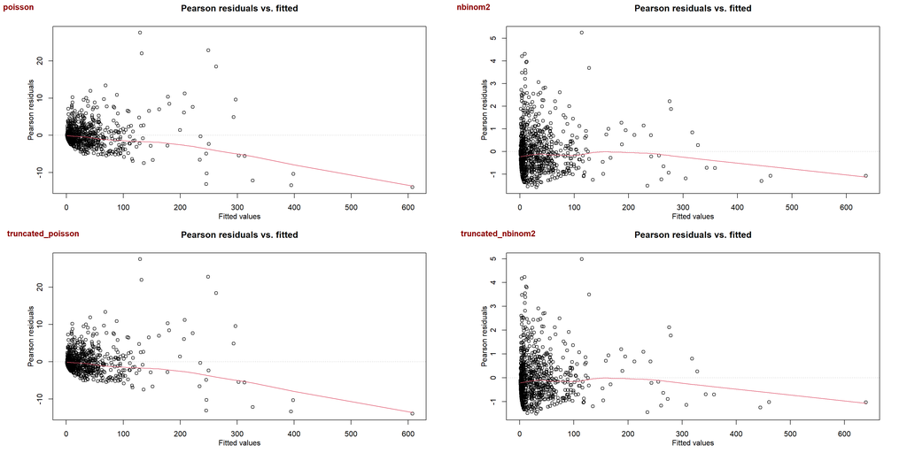

```r
res_mod_zi_1.0 <- as.ggplot(~ plotresid(mod_zi_1.0))
res_mod_zi_1.1 <- as.ggplot(~ plotresid(mod_zi_1.1))
res_mod_zi_1.2 <- as.ggplot(~ plotresid(mod_zi_1.2))
res_mod_zi_1.3 <- as.ggplot(~ plotresid(mod_zi_1.3))

ggarrange(
  res_mod_zi_1.0,
  res_mod_zi_1.1,
  res_mod_zi_1.2,
  res_mod_zi_1.3,
  ncol = 2,
  nrow = 2,
  labels = c("poisson", "nbinom2", "truncated_poisson", "truncated_nbinom2"),
  font.label = list(
    size = 13,
    color = "darkred",
    face = "bold",
    family = NULL
  ),
  hjust = -0.1,
  vjust = 1.6,
  align = c("none", "h", "v", "hv")
)
```

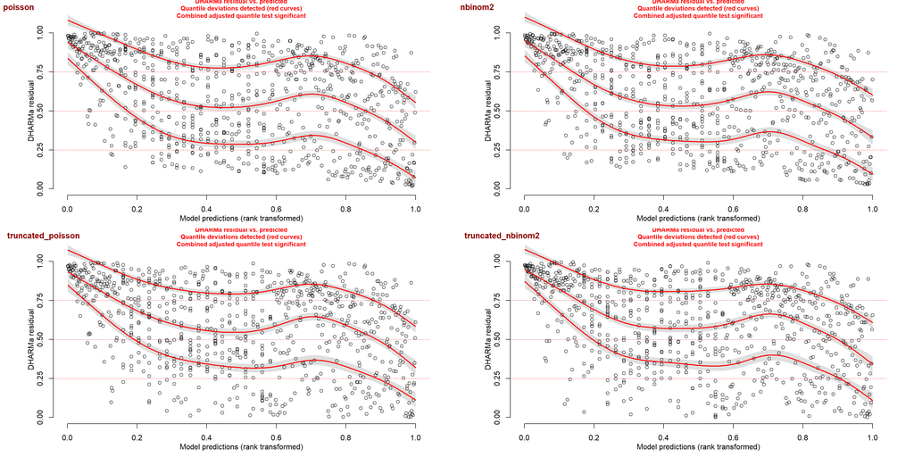

```r
sim_res_mod_zi_1.0 <- as.ggplot(~ plotResiduals(simulateResiduals(fittedModel = mod_zi_1.0, n = 1000), quantreg = T))
sim_res_mod_zi_1.1 <- as.ggplot(~ plotResiduals(simulateResiduals(fittedModel = mod_zi_1.1, n = 1000), quantreg = T))
sim_res_mod_zi_1.2 <- as.ggplot(~ plotResiduals(simulateResiduals(fittedModel = mod_zi_1.2, n = 1000), quantreg = T))
sim_res_mod_zi_1.3 <- as.ggplot(~ plotResiduals(simulateResiduals(fittedModel = mod_zi_1.3, n = 1000), quantreg = T))

ggarrange(
  sim_res_mod_zi_1.0,
  sim_res_mod_zi_1.1,
  sim_res_mod_zi_1.2,
  sim_res_mod_zi_1.3,
  ncol = 2,
  nrow = 2,
  labels = c("poisson", "nbinom2", "truncated_poisson", "truncated_nbinom2"),
  font.label = list(
    size = 13,
    color = "darkred",
    face = "bold",
    family = NULL
  ),
  hjust = -0.1,
  vjust = 1.6,
  align = c("none", "h", "v", "hv")
)
```

## 4.1 Summary du meilleur modèle

```r
summary(mod_zi_1.3)
```

```
##  Family: truncated_nbinom2  ( log )
## Formula:
## valeur ~ annee + offset(log(ope_surface_calculee)) + pro_libelle +
##     (1 | sta_id)
## Data: truite_data_sans_abs
##
##       AIC       BIC    logLik -2*log(L)  df.resid
##    6167.4    6190.9   -3078.7    6157.4       804
##
## Random effects:
##
## Conditional model:
##  Groups Name        Variance Std.Dev.
##  sta_id (Intercept) 3.49     1.868
## Number of obs: 809, groups:  sta_id, 100
##
## Dispersion parameter for truncated_nbinom2 family (): 3.11
##
## Conditional model:
##                                                       Estimate Std. Error
## (Intercept)                                          28.511894   9.307772
## annee                                                -0.016121   0.004616
## pro_libellePêche partielle par points (grand milieu) -1.130207   0.391173
##                                                      z value Pr(>|z|)
## (Intercept)                                            3.063 0.002190 **
## annee                                                 -3.493 0.000478 ***
## pro_libellePêche partielle par points (grand milieu)  -2.889 0.003861 **
## ---
## Signif. codes:  0 '***' 0.001 '**' 0.01 '*' 0.05 '.' 0.1 ' ' 1
```

```r
Anova(mod_zi_1.3)
```

```
## Analysis of Deviance Table (Type II Wald chisquare tests)
##
## Response: valeur
##               Chisq Df Pr(>Chisq)
## annee       12.1980  1  0.0004784 ***
## pro_libelle  8.3479  1  0.0038613 **
## ---
## Signif. codes:  0 '***' 0.001 '**' 0.01 '*' 0.05 '.' 0.1 ' ' 1
```